# Numerical Methods for PDEs (Spring 2017), Lab 4

Richard Southwell, Gustav Delius

# Encapsulating code in a function

In the last lab you wrote code to use the forward difference method to numerically solve the heat equation
$$u_{t}(x,t) = K u_{xx}(x,t)+f(x),$$
for $0<x< L, 0<t<T$, subject to the boundary conditions
$$u(0, t) = u(L, t)=0,$$
and initial condition
$$u(x, 0) = u_0(x).$$
To make it easy to re-use that code to obtain solutions with different parameters and different choices for the initial condition $u_0(x)$ and the inhomogenous term $f(x)$ we encapsulate that code inside a function. The parameters that we may want to change we make into arguments for the function.

```r
forwardDifference <- function(f=function(x) 0,
                              u0=function(x) 2*sin(2*pi*x),
                              K=1, L=1, N=30, T=0.1, M=200) {
    # set up space grid
    h <- L/N
    x <- h*(1:(N-1))

    # set up time grid
    tau <- T/M
    t <- tau*(0:M)

    # set up vectors with initial condition and inhomogenous term
    w <- u0(x)
    F <- f(x)

    # Set up evolution matrix
    gamma <- K*tau/(h^2)
    A <- diag(1-2*gamma, N-1)
    for (k in 1:(N-2)) {
        A[k,k+1] <- gamma
        A[k+1,k] <- gamma
    }

    Temperature <- matrix(0, N-1, M+1)  # Matrix to hold the solution
    Temperature[ , 1] <- w  # Initial value
    # Loop over time steps
    for (j in 1:M) {
        w <- A %*% w + tau * F
        Temperature[ , j+1] <- w
    }

    # Return a list consisting of time grid, x grid and solution
    return(list(x=x, t=t, w=Temperature))
}
```

There are two things to note about the function arguments:

1. R allows the arguments to functions to themselves be functions. In the above function the arguments `f` and `u0` are functions.
2. R allows you to specify default values for some arguments. Then you can call the function without having to specify those arguments where you just want to use the default values

Let us use this function to reproduce the first example from Lab 3

```r
sol <- forwardDifference()
```

Note that we did not have to specify any of the arguments because we were happy with the default values.

Next we plot the solution:

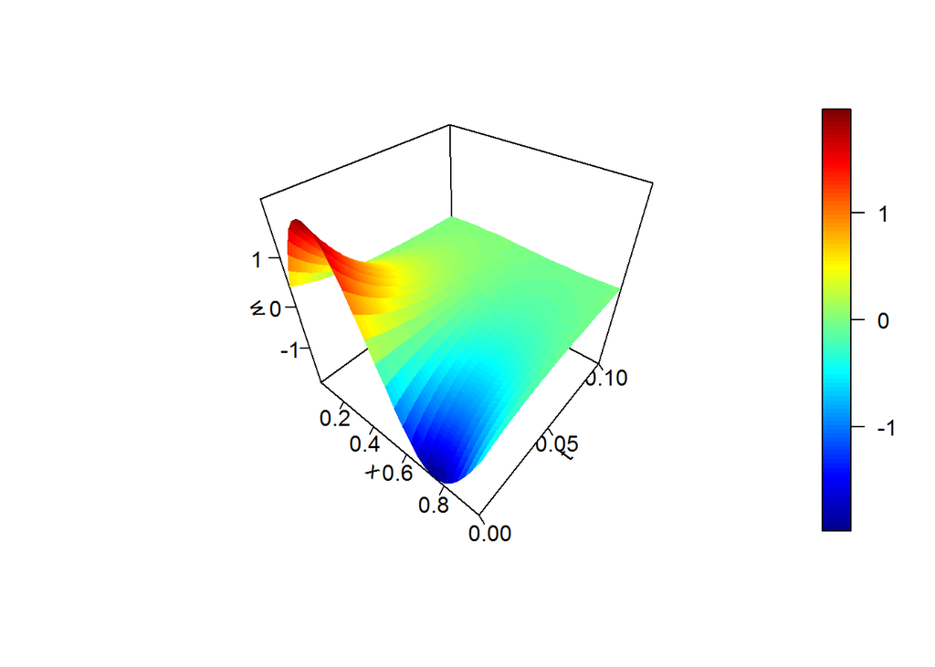

```r
library("plot3Drgl")
persp3D(sol$x, sol$t, sol$w,
        xlab="x", ylab="t", zlab="w",
        ticktype="detailed", nticks=4)
```

We send the plot to a separate window so we can interact with it:

```r
plotrgl(smooth=TRUE, lighting = TRUE)
```

Next let’s reproduce the the example from the last exercise from Lab 3.

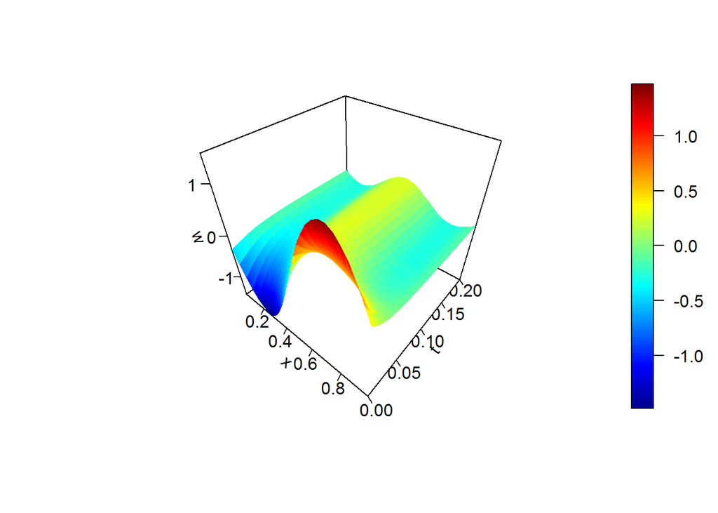

```r
sol <- forwardDifference(f=function(x) {-25*sin(3*pi*x)},
                         u0=function(x) {-1.5*sin(2*pi*x)},
                         T=0.2, M=400
)
persp3D(sol$x, sol$t, sol$w,
        xlab="x", ylab="t", zlab="w",
        ticktype="detailed", nticks=4)
```

## Exercise 1

Use the function `forwardDifference()` to solve the equation
$$u_{t}(x,t) = \frac14 u_{xx}(x,t)-16\sin(8\pi x), \quad
0<x< 1, \quad 0<t<0.2$$
with initial condition
$$u(0, t) = u(1, t)=0, \quad u(x, 0) = \sin(\pi x).$$
Plot the solution.

# Studying the error

Consider again the example from the exercise in Lab 3:
$$u_{t}(x,t) = u_{xx}(x,t)-25 \sin(3\pi x), \quad
0<x< 1, \quad 0<t<0.2,$$
with initial condition
$$u(0, t) = u(1, t)=0, \quad u(x, 0) = -\frac32\sin(2\pi x).$$

The exact solution is
$$u(x,t) = -\frac32 \sin(2\pi x)e^{-4\pi^2 t}
-\frac{25}{9\pi^2}\sin(3\pi x)\left(1-e^{-9\pi^2 t}\right).$$

We will now compare the numerical solution to the exact solution. The numerical solution is

```r
numSol <- forwardDifference(f=function(x) {-25*sin(3*pi*x)},
                         u0=function(x) {-3/2*sin(2*pi*x)},
                         T=0.2, M=360
)
```

To evaluate the exact solution at the grid points we first construct the grid (mesh)

```r
x <- numSol$x
t <- numSol$t
xy <- mesh(x, t)
```

and then create the matrix of values at the grid points

```r
u <- with(xy, -3/2*sin(2*pi*x)*exp(-4*pi^2*y)
                       -25/(9*pi^2)*sin(3*pi*x)*(1-exp(-9*pi^2*y)))
```

When we plot the exact solution it looks just like the numerical solutions we had plotted already above.

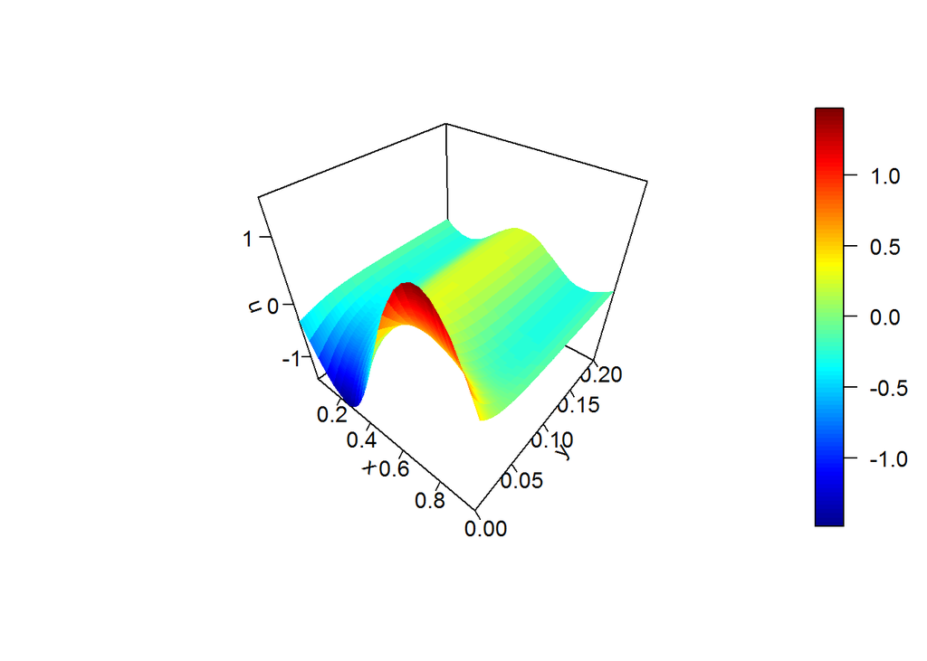

```r
persp3D(x, t, u, zlab="u", ticktype="detailed", nticks=4)
```

But when we plot the difference between the numerical solution and the exact solution we see that they were in fact not quite equal.

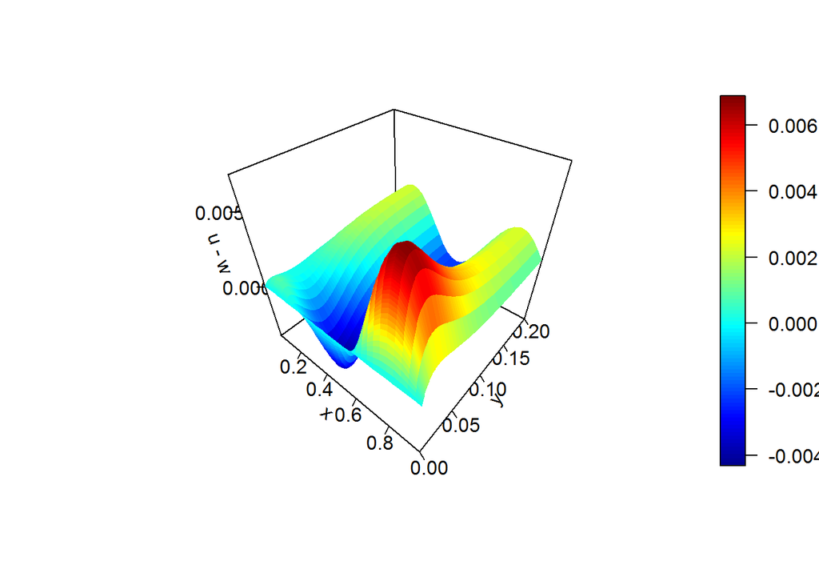

```r
persp3D(x, t, u - numSol$w, zlab="u - w", ticktype="detailed", nticks=4)
```

There is quite a large error. The maximal error is

```r
max(abs(u - numSol$w))
```

```
[1] 0.006975107
```

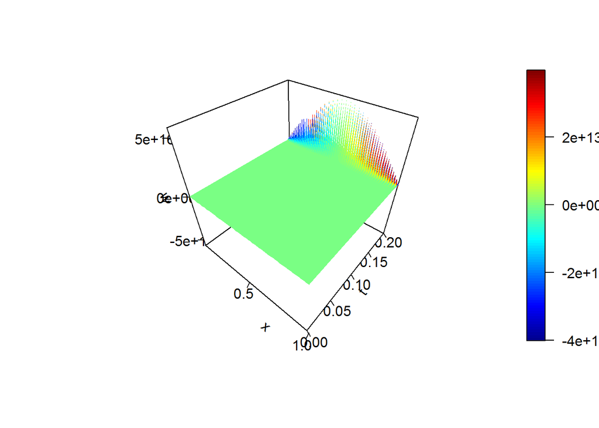

```r
numSol <- forwardDifference(f=function(x) {-25*sin(3*pi*x)},
                         u0=function(x) {-3/2*sin(2*pi*x)},
                         T=0.2, M=1400, N=60
)
persp3D(numSol$x, numSol$t, numSol$w,
        xlab="x", ylab="t", zlab="w",
        ticktype="detailed", nticks=4)
```

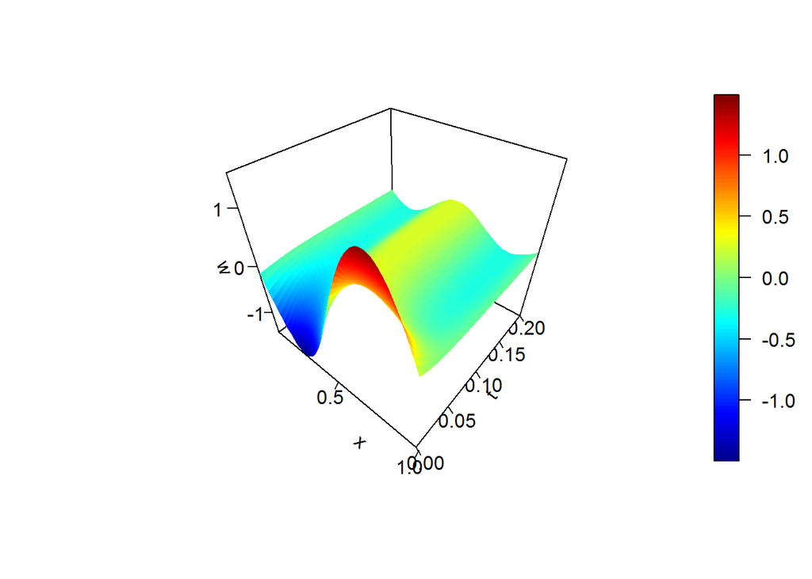

```r
numSol <- forwardDifference(f=function(x) {-25*sin(3*pi*x)},
                         u0=function(x) {-3/2*sin(2*pi*x)},
                         T=0.2, M=1440, N=60
)
persp3D(numSol$x, numSol$t, numSol$w,
        xlab="x", ylab="t", zlab="w",
        ticktype="detailed", nticks=4)
```

Notice that now we have approximations $w$ at many more gridpoints. The resolution in the $t$ direction is much larger than we need to produce a nice plot. This unnecessarily slows down the production of the plot, so we will work only with a subset of all the $t$ values. Out of the 1441 values we will plot only every 4th. Luckily selecting a subset of entries of a vector or a matrix is very easy in R. We first introduce the technique in a simple example.

```r
v <- (1:10)^2
v
```

```
 [1]   1   4   9  16  25  36  49  64  81 100
```

Here is how we would select the third and sixth element from the vector `v`:

```r
v[c(3, 6)]
```

```
[1]  9 36
```

To select only all elements with odd indices we can do

```r
select <- seq(1, 10, by=2)
v[select]
```

```
[1]  1  9 25 49 81
```

We can now apply this technique to extracting every 4th element in the $t$ direction.

```r
tSelect <- seq(1, 1441, by=4)
t <- numSol$t[tSelect]
w <- numSol$w[, tSelect]
```

We calculate the exact solution at the same gridpoints

```r
x <- numSol$x
xy <- mesh(x, t)
u <- with(xy, -3/2*sin(2*pi*x)*exp(-4*pi^2*y)
                       -25/(9*pi^2)*sin(3*pi*x)*(1-exp(-9*pi^2*y)))
```

Now we can plot the difference between the exact solution and the numerical solution

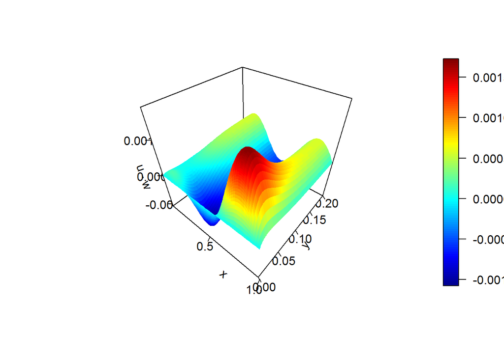

```r
persp3D(x, t, u - w, zlab="u - w", ticktype="detailed", nticks=4)
```

The error has indeed been reduced by a factor of about $4$ by decreasing the step-size $h$ by a factor of $2$. For example the maximal error is now

```r
max(abs(u - w))
```

```
[1] 0.001731441
```

## Exercise 2

Determine the maximal error when you use a step-size of $h=1/120$. Keep on doubling the number of steps in the $x$ directions. Does the error continue to decrease as expected? What happens to the running time of the code?

## Exercise 3

Similarly calculate the maximal error in the numerical solution from exercise 1, again for a range of step-sizes.

## Exercise 4 (Challenge)

Write code that produces a plot of the maximal error against the number of steps $M$.